# Machine Learning 1

Assignment 1 - CEU 2018

Cagdas Yetkin, Business Analytics Part Time

2018-01-28

## Packages

```r
library(caret)
library(data.table)
library(purrr)
library(GGally)
library(dplyr)
library(descr)
library(imputeR)
library(tidyr)
```

# Model selection with a validation set

Take the real estate dataset used in class and make log_price your target variable

```r
data <- fread("kc_house_data.csv")

data[, `:=`(floors = as.numeric(floors), zipcode = factor(zipcode))]
data[, log_price := log(price)]

data[, c("id", "date", "sqft_living15", "sqft_lot15", "price") := NULL]

set.seed(1234)
```

cut your data into three parts: 50% should be your training data, 25% each your validation and test sets (cut data into two parts, then further cut one part into two)

```r
my_ratio <- 0.5
train_indices <- createDataPartition(y = data[["log_price"]],
                                     times = 1,
                                     p = my_ratio,
                                     list = FALSE)

data_train     <- data[train_indices, ]
data_remaining <- data[-train_indices, ]

val_test_indices <- createDataPartition(y = data_remaining[["log_price"]],
                                     times = 1,
                                     p = my_ratio,
                                     list = FALSE)

data_validation <- data_remaining[val_test_indices, ]
data_test       <- data_remaining[-val_test_indices, ]
```

Train three models on the training data via caret, without cross validation (method = “none”):

a linear model lm with only using sqft_living as a predictor (a simple benchmark)

a linear model lm using all available features

a regression tree (rpart) with cp = 0.0001 (the tune grid should be a dataframe with one column cp and one row with value 0.0001)

For lm models, the tuneGrid argument should not be specified.

```r
train_control <- trainControl(method = "none")
simple_linear_fit <- train(log_price ~ sqft_living,
                  data = data_train,
                  method = "lm",
                  trControl = train_control)

linear_fit <- train(log_price ~ .,
                  data = data_train,
                  method = "lm",
                  trControl = train_control)

tune_grid <- data.frame("cp" = c(0.0001))
rpart_fit <- train(log_price ~ .,
                   data = data_train,
                   method = "rpart",
                   trControl = train_control,
                   tuneGrid = tune_grid)
```

Compare your models on the validation set and choose the one with the best performance (using RMSE). Use predict.train for prediction just like we used predict in class.

```r
RMSE <- function(x, true_x) sqrt(mean((x - true_x)^2))


simple_linear_rmse <- RMSE(predict.train(simple_linear_fit, newdata = data_validation, type = 'raw'), data_validation$log_price)

simple_linear_rmse
```

```
## [1] 0.3797396
```

```r
linear_rmse <- RMSE(predict.train(linear_fit, newdata = data_validation, type = 'raw'), data_validation$log_price)
linear_rmse
```

```
## [1] 0.190462
```

```r
rpart_rmse <- RMSE(predict.train(rpart_fit, newdata = data_validation, type = 'raw'), data_validation$log_price)
rpart_rmse
```

```
## [1] 0.2192006
```

Evaluate the final model on the test set. Why is it important to have this final set of observations set aside for evaluation? (Hint: think about what we used the validation set for.)

```r
final_performance_measure <- RMSE(predict.train(linear_fit, newdata = data_test, type = 'raw'), data_test$log_price)
final_performance_measure
```

```
## [1] 0.1885708
```

# Predicting developer salaries

```r
data <- fread("survey_results_public_selected.csv")

data <- data[!is.na(Salary) & Salary > 0]
data <- data[complete.cases(data)]
data <- data[, Gender := ifelse(Gender == "Male", "Male",
                              ifelse(Gender == "Female", "Female", "Other"))]
large_countries <- data[, .N, by = "Country"][N > 60][["Country"]]
data <- data[, Country := ifelse(Country %in% large_countries, Country, "Other")]
```

1. Describe what the data cleansing steps mean: 1) Keep the observations where the Salary is not NA and greater than zero. 2) Apply complete_cases on top of it to have only the cases without missing values. However, we will need to fix the missing values in Gender column separetely. 3) Update the gender column to write ‘Other’ for the observations where there is no gender recorded. Actually it was empty string. 4) Create a vector for the large countries which have more than 60 observations in data 5) Update the country column in data by using this vector to have country name if it is a large country, call it ‘Other’ if not.
2. Using graphs, find at least two interesting features that can contribute to understanding developer salaries

Look at the outcome variable, Salary.

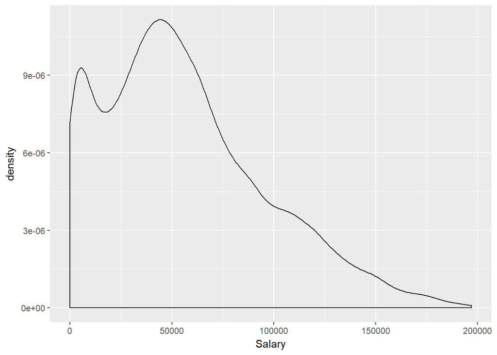

```r
ggplot(data, aes(Salary)) + geom_density()
```

We might want to see the log Salary since we see a right skewed output. Bimodal shape is also creeping in my brain.

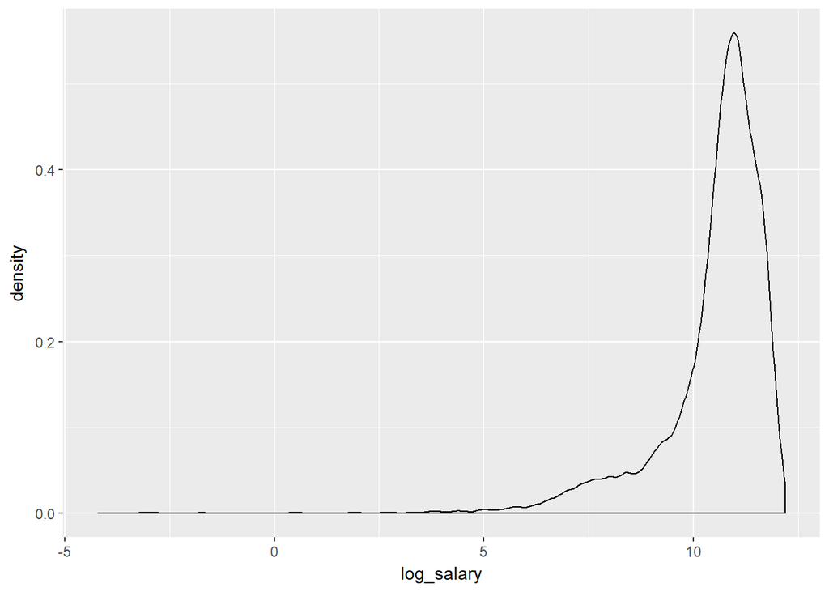

```r
data[, log_salary := log(Salary)]

ggplot(data, aes(log_salary)) + geom_density()
```

In fact we don’t see a nice log-normal but it will not stop us from trying out some models with log Salaries.

```r
names(data)
```

```
## [1] "Salary"          "TabsSpaces"      "YearsProgram"    "Country"
## [5] "Gender"          "FormalEducation" "ProgramHobby"    "CompanySize"
## [9] "log_salary"
```

```r
data[, .N, by = TabsSpaces][order(N, decreasing = T)]
```

| TabsSpaces | N |
| --- | --- |
| Spaces | 5511 |
| Tabs | 5033 |
| Both | 1877 |
|  | 464 |

```r
data[, .N, by = YearsProgram][order(N, decreasing = T)]
```

| YearsProgram | N |
| --- | --- |
| 20 or more years | 2578 |
| 9 to 10 years | 964 |
| 5 to 6 years | 792 |
| 4 to 5 years | 789 |
| 10 to 11 years | 727 |
| 6 to 7 years | 718 |
| 7 to 8 years | 692 |
| 14 to 15 years | 652 |
| 3 to 4 years | 609 |
| 15 to 16 years | 572 |

[output cut: 12 more lines]

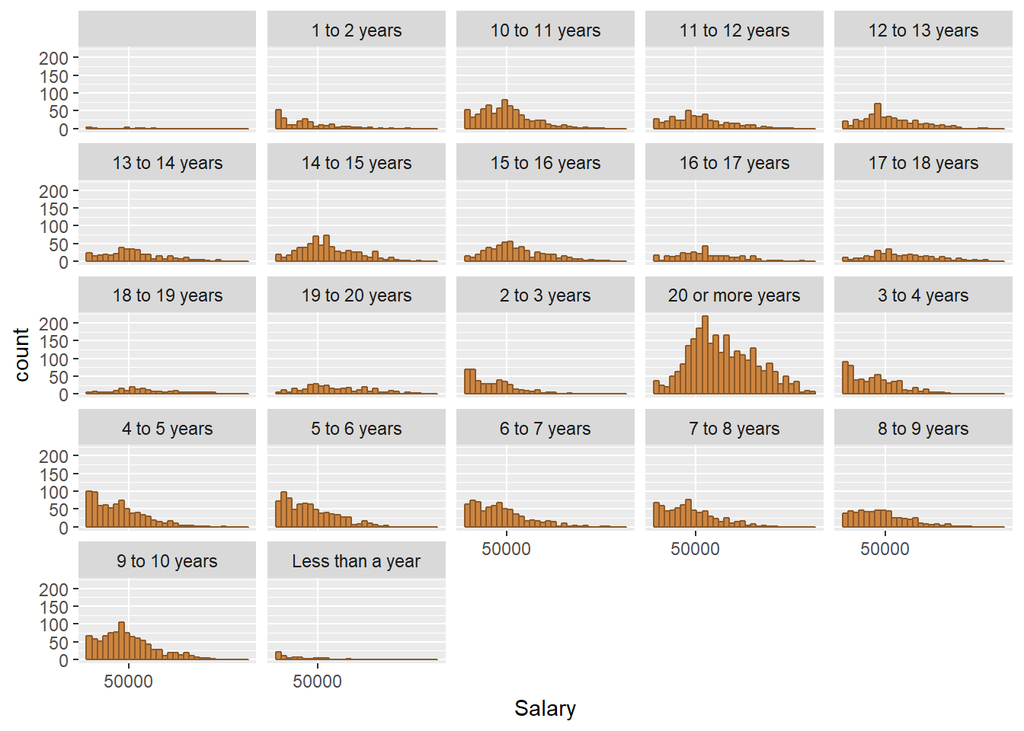

```r
ggplot(data, aes(Salary)) +
    geom_histogram(fill = "tan3", color= "tan4") +
    facet_wrap(~YearsProgram) + scale_x_continuous(breaks = 50000)
```

```r
data[, .N, by = Country][order(N, decreasing = T)]
```

| Country | N |
| --- | --- |
| United States | 3781 |
| United Kingdom | 1386 |
| Germany | 994 |
| Other | 990 |
| India | 819 |
| Canada | 667 |
| France | 477 |
| Poland | 317 |
| Spain | 278 |
| Australia | 255 |

[output cut: 25 more lines]

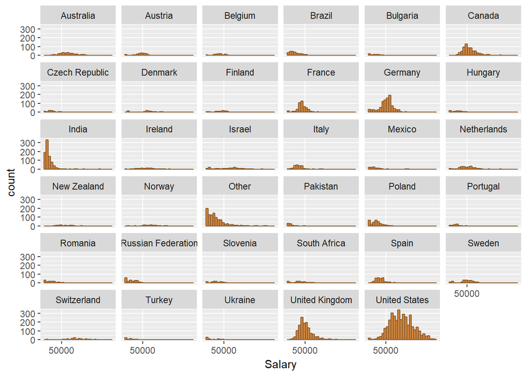

```r
data[, salary_avg := mean(Salary), by = Country]

ggplot(data, aes(Salary)) +
    geom_histogram(fill = "tan3", color= "tan4") +
    facet_wrap(~Country) + scale_x_continuous(breaks = 50000)
```

A quick look reveals that Salaries in India and Others (small countries) are causing that bimodal shape in the Salary density plot. Country really matters!

```r
data[, .N, by = Gender][order(N, decreasing = T)]
```

| Gender | N |
| --- | --- |
| Male | 10664 |
| Other | 1403 |
| Female | 818 |

```r
data[, .N, by = FormalEducation][order(N, decreasing = T)]
```

| FormalEducation | N |
| --- | --- |
| Bachelor's degree | 6403 |
| Master's degree | 3077 |
| Some college/university study without earning a bachelor's degree | 2049 |
| Secondary school | 760 |
| Doctoral degree | 293 |
| Professional degree | 143 |
| I never completed any formal education | 60 |
| Primary/elementary school | 55 |
| I prefer not to answer | 45 |

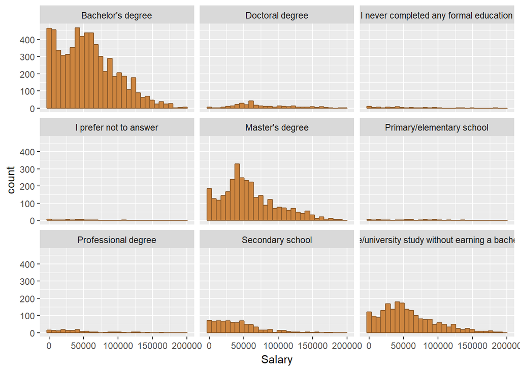

```r
ggplot(data, aes(Salary)) +
    geom_histogram(fill = "tan3", color= "tan4") +
    facet_wrap(~FormalEducation)
```

```r
data[, .N, by = ProgramHobby][order(N, decreasing = T)]
```

| ProgramHobby | N |
| --- | --- |
| Yes, I program as a hobby | 6130 |
| Yes, both | 3621 |
| No | 2440 |
| Yes, I contribute to open source projects | 694 |

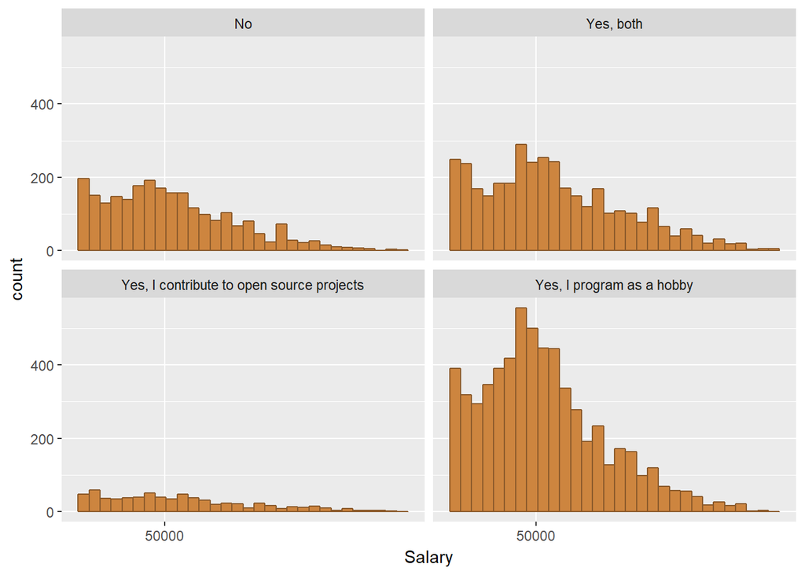

```r
ggplot(data, aes(Salary)) +
    geom_histogram(fill = "tan3", color= "tan4") +
    facet_wrap(~ProgramHobby) + scale_x_continuous(breaks = 50000)
```

```r
data[, .N, by = CompanySize][order(N, decreasing = T)]
```

| CompanySize | N |
| --- | --- |
| 20 to 99 employees | 3065 |
| 100 to 499 employees | 2609 |
| 10,000 or more employees | 1823 |
| 10 to 19 employees | 1335 |
| 1,000 to 4,999 employees | 1288 |
| Fewer than 10 employees | 1182 |
| 500 to 999 employees | 851 |
| 5,000 to 9,999 employees | 519 |
| I don't know | 161 |
| I prefer not to answer | 41 |

[output cut: 1 more lines]

I have 11 observations missing for Company Size and YearsProgram.

I have also 464 missing for TabsSpaces. Are they missing at random is the question. It looks like they are similar to the distributions of the entire data.

The people who didn’t give TabSpace information also didn’t give their Gender information. Looks like these people don’t want to share much info about themselves. I don’t think all of them are gay.

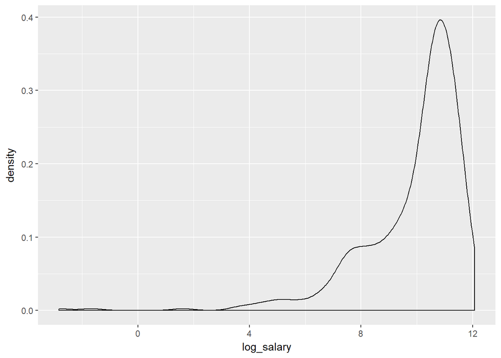

```r
NoInfoTabSpaces <- data[TabsSpaces == '']
ggplot(NoInfoTabSpaces, aes(log_salary)) + geom_density()
```

```r
NoInfoTabSpaces[, .N, by = Country][order(N, decreasing = T)]
```

| Country | N |
| --- | --- |
| United States | 106 |
| India | 74 |
| United Kingdom | 52 |
| Other | 39 |
| Germany | 25 |
| Spain | 18 |
| Canada | 18 |
| France | 15 |
| Brazil | 11 |
| Russian Federation | 11 |

[output cut: 24 more lines]

```r
NoInfoTabSpaces[, .N, by = Gender]
```

| Gender | N |
| --- | --- |
| Other | 434 |
| Male | 28 |
| Female | 2 |

```r
NoInfoTabSpaces[, .N, by = YearsProgram][order(N, decreasing = T)]
```

| YearsProgram | N |
| --- | --- |
| 20 or more years | 57 |
| 5 to 6 years | 42 |
| 4 to 5 years | 37 |
| 3 to 4 years | 35 |
| 6 to 7 years | 35 |
| 9 to 10 years | 30 |
| 2 to 3 years | 25 |
| 14 to 15 years | 25 |
| 1 to 2 years | 23 |
| 7 to 8 years | 21 |

[output cut: 12 more lines]

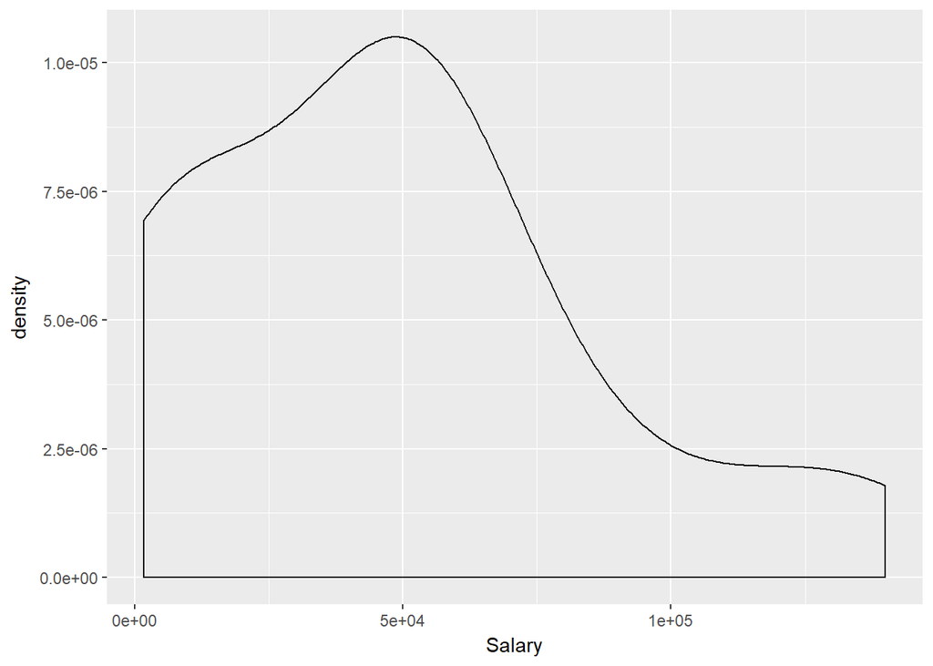

```r
NoInfoCompYears <- data[CompanySize == '' | YearsProgram == '']
ggplot(NoInfoCompYears, aes(Salary)) + geom_density()
```

```r
data <- data[TabsSpaces=='', TabsSpaces := ifelse(YearsProgram == "20 or more years", "Spaces",
                              ifelse(Gender == "Female", "Female", "Other"))]
```

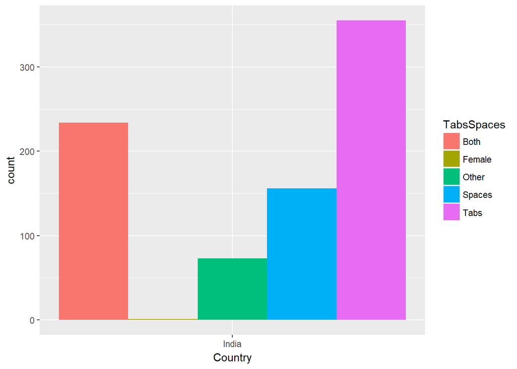

```r
ggplot(data[Country== 'India'], aes(Country, ..count..)) + geom_bar(aes(fill = TabsSpaces), position = "dodge")
```

3. Create a training and a test set assigning 70% to the training set and 30% as the test set.

```r
set.seed(123)
my_ratio <- 0.7
train_indices <- createDataPartition(y = data[["log_salary"]],
                                     times = 1,
                                     p = my_ratio,
                                     list = FALSE)

data_train <- data[train_indices, ]
data_train <- data_train[, Salary := NULL]
data_test  <- data[-train_indices, ]
```

4. Using caret train at least two predictive models to predict the logarithm of Salary (they can be of the same family but with different hyperparameters or they can be of different families like we used lm and rpart in the first exercise). Make sure NOT to include Salary as a predictor variable. Also, just before calling train, remember to use set.seed

```r
set.seed(123)
train_control <- trainControl(method = "repeatedcv", number = 5, repeats = 3)

linear_fit <- train(log_salary ~ .,
                  data = data_train,
                  method = "lm",
                  trControl = train_control)
```

[output not shown]

```r
tune_grid <- data.frame("cp" = c(0.0001))
rpart_fit <- train(log_salary ~ .,
                   data = data_train,
                   method = "rpart",
                   preProcess=c("medianImpute", "center", "scale"),
                   trControl = train_control,
                   tuneGrid = tune_grid)
linear_fit
```

```
## Linear Regression
##
## 9020 samples
##    8 predictor
##
## No pre-processing
## Resampling: Cross-Validated (5 fold, repeated 3 times)
## Summary of sample sizes: 7216, 7216, 7216, 7217, 7215, 7217, ...
## Resampling results:
##
##   RMSE       Rsquared   MAE
##   0.9639893  0.4932157  0.5373426
##
## Tuning parameter 'intercept' was held constant at a value of TRUE
```

```r
rpart_fit
```

```
## CART
##
## 9020 samples
##    8 predictor
##
## Pre-processing: median imputation (83), centered (83), scaled (83)
## Resampling: Cross-Validated (5 fold, repeated 3 times)
## Summary of sample sizes: 7216, 7217, 7216, 7215, 7216, 7216, ...
## Resampling results:
##
##   RMSE      Rsquared   MAE
##   1.026201  0.4366102  0.5771076
##
## Tuning parameter 'cp' was held constant at a value of 1e-04
```

5. evaluate its performance on the test set

```r
postResample(data_test$log_salary, predict(linear_fit, data_test))
```

```
##      RMSE  Rsquared       MAE
## 0.9486285 0.4901465 0.5368678
```

# Leave-one-out cross validation

1. This can be a very expensive computation for large dataset and this is a disadvantage
2. Basically all the observations have labelled target values and we are maximizing our validation. This is the maximum number of tests we can.

```r
library(titanic)
library(data.table)

data_train <- data.table(titanic_train)
# recode Survived to factor - needed for binary prediction
data_train[, Survived := factor(ifelse(Survived == 1, "survived", "died"))]
data_train[, Sex := factor(Sex)]
sapply(data_train, function(x) {sum(is.na(x))})
```

```
## PassengerId    Survived      Pclass        Name         Sex         Age
##           0           0           0           0           0         177
##       SibSp       Parch      Ticket        Fare       Cabin    Embarked
##           0           0           0           0           0           0
```

```r
data_train[, Age := ifelse(is.na(Age), median(Age, na.rm = T), Age), by = Fare]
data_train[, Age := ifelse(is.na(Age), median(Age, na.rm = T), Age)]
str(data_train)
```

```
## Classes 'data.table' and 'data.frame':   891 obs. of  12 variables:
##  $ PassengerId: int  1 2 3 4 5 6 7 8 9 10 ...
##  $ Survived   : Factor w/ 2 levels "died","survived": 1 2 2 2 1 1 1 1 2 2 ...
##  $ Pclass     : int  3 1 3 1 3 3 1 3 3 2 ...
##  $ Name       : chr  "Braund, Mr. Owen Harris" "Cumings, Mrs. John Bradley (Florence Briggs Thayer)" "Heikkinen, Miss. Laina" "Futrelle, Mrs. Jacques Heath (Lily May Peel)" ...
##  $ Sex        : Factor w/ 2 levels "female","male": 2 1 1 1 2 2 2 2 1 1 ...
##  $ Age        : num  22 38 26 35 35 29 54 2 27 14 ...
##  $ SibSp      : int  1 1 0 1 0 0 0 3 0 1 ...
##  $ Parch      : int  0 0 0 0 0 0 0 1 2 0 ...
##  $ Ticket     : chr  "A/5 21171" "PC 17599" "STON/O2. 3101282" "113803" ...
##  $ Fare       : num  7.25 71.28 7.92 53.1 8.05 ...
##  $ Cabin      : chr  "" "C85" "" "C123" ...
##  $ Embarked   : chr  "S" "C" "S" "S" ...
##  - attr(*, ".internal.selfref")=<externalptr>
```

```r
summary(data_train)
```

```
##   PassengerId        Survived       Pclass          Name
##  Min.   :  1.0   died    :549   Min.   :1.000   Length:891
##  1st Qu.:223.5   survived:342   1st Qu.:2.000   Class :character
##  Median :446.0                  Median :3.000   Mode  :character
##  Mean   :446.0                  Mean   :2.309
##  3rd Qu.:668.5                  3rd Qu.:3.000
##  Max.   :891.0                  Max.   :3.000
##      Sex           Age            SibSp           Parch
##  female:314   Min.   : 0.42   Min.   :0.000   Min.   :0.0000
##  male  :577   1st Qu.:22.00   1st Qu.:0.000   1st Qu.:0.0000
##               Median :29.00   Median :0.000   Median :0.0000
##               Mean   :29.84   Mean   :0.523   Mean   :0.3816
##               3rd Qu.:36.00   3rd Qu.:1.000   3rd Qu.:0.0000
##               Max.   :80.00   Max.   :8.000   Max.   :6.0000
##     Ticket               Fare           Cabin             Embarked
##  Length:891         Min.   :  0.00   Length:891         Length:891
##  Class :character   1st Qu.:  7.91   Class :character   Class :character
##  Mode  :character   Median : 14.45   Mode  :character   Mode  :character
##                     Mean   : 32.20
##                     3rd Qu.: 31.00
##                     Max.   :512.33
```

```r
glimpse(data_train)
```

```
## Observations: 891
## Variables: 12
## $ PassengerId <int> 1, 2, 3, 4, 5, 6, 7, 8, 9, 10, 11, 12, 13, 14, 15,...
## $ Survived    <fctr> died, survived, survived, survived, died, died, d...
## $ Pclass      <int> 3, 1, 3, 1, 3, 3, 1, 3, 3, 2, 3, 1, 3, 3, 3, 2, 3,...
## $ Name        <chr> "Braund, Mr. Owen Harris", "Cumings, Mrs. John Bra...
## $ Sex         <fctr> male, female, female, female, male, male, male, m...
## $ Age         <dbl> 22.0, 38.0, 26.0, 35.0, 35.0, 29.0, 54.0, 2.0, 27....
## $ SibSp       <int> 1, 1, 0, 1, 0, 0, 0, 3, 0, 1, 1, 0, 0, 1, 0, 0, 4,...
## $ Parch       <int> 0, 0, 0, 0, 0, 0, 0, 1, 2, 0, 1, 0, 0, 5, 0, 0, 1,...
## $ Ticket      <chr> "A/5 21171", "PC 17599", "STON/O2. 3101282", "1138...
## $ Fare        <dbl> 7.2500, 71.2833, 7.9250, 53.1000, 8.0500, 8.4583, ...
## $ Cabin       <chr> "", "C85", "", "C123", "", "", "E46", "", "", "", ...
## $ Embarked    <chr> "S", "C", "S", "S", "S", "Q", "S", "S", "S", "C", ...
```

```r
set.seed(123)
trctrl <- trainControl(method = "loocv",
                       classProbs = TRUE)

loocv_model <- train(Survived ~ Fare + Sex,
                 data = data_train,
                 method = "glm",
                 trControl=trctrl,
                 preProcess=c("center", "scale"))
                 #tuneLength=5)

loocv_model
```

```
## Generalized Linear Model
##
## 891 samples
##   2 predictor
##   2 classes: 'died', 'survived'
##
## Pre-processing: centered (2), scaled (2)
## Resampling: Leave-One-Out Cross-Validation
## Summary of sample sizes: 890, 890, 890, 890, 890, 890, ...
## Resampling results:
##
##   Accuracy   Kappa
##   0.7822671  0
```

and a 10-fold cross-validation estimation using only Fare and Sex as predictor features

```r
set.seed(123)
trctrl <- trainControl(method = "cv",
                       number = 10,
                       classProbs = TRUE)

cv10_model <- train(Survived ~ Fare + Sex,
                 data = data_train,
                 method = "glm",
                 trControl=trctrl,
                 preProcess=c("center", "scale"))
                 #tuneLength=5)

cv10_model
```

```
## Generalized Linear Model
##
## 891 samples
##   2 predictor
##   2 classes: 'died', 'survived'
##
## Pre-processing: centered (2), scaled (2)
## Resampling: Cross-Validated (10 fold)
## Summary of sample sizes: 802, 801, 803, 802, 802, 802, ...
## Resampling results:
##
##   Accuracy   Kappa
##   0.7812311  0.5322049
```

```r
summary(cv10_model$resample)
```

```
##     Accuracy          Kappa          Resample
##  Min.   :0.7111   Min.   :0.3727   Length:10
##  1st Qu.:0.7697   1st Qu.:0.5025   Class :character
##  Median :0.7921   Median :0.5651   Mode  :character
##  Mean   :0.7812   Mean   :0.5322
##  3rd Qu.:0.7994   3rd Qu.:0.5783
##  Max.   :0.8090   Max.   :0.5858
```

```r
summary(loocv_model$resample)
```

```
##     Accuracy          Kappa       Resample
##  Min.   :0.0000   Min.   :0     Length:891
##  1st Qu.:1.0000   1st Qu.:0     Class :character
##  Median :1.0000   Median :0     Mode  :character
##  Mean   :0.7823   Mean   :0
##  3rd Qu.:1.0000   3rd Qu.:0
##  Max.   :1.0000   Max.   :0
##                   NA's   :697
```

In sample accuracy is a bit better for LOOCV (78.23% to 78.12%). Doing so many validations can give some boosting effect to our model. However, the threshold between computation time and the business objectives should be carefully assessed.